# TP — Séries temporelles batterie et identification d'un modèle électrique avec JAX

Dans ce TP, on étudie plusieurs semaines de données synthétiques correspondant à l'utilisation d'un véhicule électrique équipé d'un pack batterie fictif.

Le pack considéré possède notamment :

- une capacité nominale d'environ **250 Ah** ;
- une tension nominale d'environ **200 V** ;
- une énergie nominale d'environ

$$ E_{\mathrm{nom}} \approx U_{\mathrm{nom}}\,C_{\max} = 200\times250 = 50\,000\ \mathrm{Wh} $$

soit environ :

$$ \boxed{50\ \mathrm{kWh}} $$

Les données contiennent principalement :

- le courant batterie ;
- la tension pack ;
- la température ;
- le temps.

L'objectif du TP est d'abord de se familiariser avec la structure de longues séries temporelles issues d'un usage véhicule, puis de construire progressivement un modèle permettant de reproduire la tension mesurée.

Le TP est organisé en plusieurs étapes :

**Exploration des séries temporelles**

- visualisation du courant, de la tension et de la température ;
- observation de différents scénarios d'usage ;
- identification des phases de charge, de décharge et de repos ;
- analyse des trous temporels et de l'échantillonnage.

**Construction d'un modèle électrique équivalent**

- relation entre courant, SOC, OCV et tension ;
- introduction d'une résistance ohmique et de branches RC ;
- discrétisation et simulation du modèle dynamique.

**Identification des paramètres du modèle**

- comparaison tension mesurée / tension simulée ;
- utilisation de l'autodifférentiation avec JAX ;
- optimisation des paramètres du modèle.

**Analyse des résultats**

- reconstruction du SOC ;
- étude des résidus ;
- comparaison des paramètres identifiés aux valeurs utilisées pour générer les données ;
- discussion sur l'identifiabilité du modèle.

# 0. Installation et imports

```python
# Installation de optax pour l'optimisation en lien avec JAX et de equinox pour
# faire de la programmation orientée objet
!pip -q install equinox optax

import numpy as np
import pandas as pd
import matplotlib.pyplot as plt
import jax
import jax.numpy as jnp
import equinox as eqx
import optax
import time

from mpl_toolkits.mplot3d import Axes3D # Figure 3D

jax.config.update("jax_enable_x64",True)
```

```python
# Charte graphique du TP
COLOR_U="tab:blue"
COLOR_I="tab:orange"
COLOR_T="tab:red"
COLOR_SOC="tab:green"

R0_CMAP="viridis"
```

```python
# ============================================================
# PARAMÈTRES MODIFIABLES — valeurs par défaut
# ============================================================

DOWNSAMPLE_STEP=5
MAX_GAP_S=60.0

N_TEST_SPEED=5000

LEARNING_RATE=1e-2
N_EPOCHS_SINGLE=1000
N_EPOCHS_DOUBLE=1000
N_EPOCHS_IDENT=500

DISPLAY_R0_EVERY=2
DISPLAY_R0_UNTIL=30
PRINT_EVERY=100

LAMBDA_CONT=1e3

ZOOM_START=5000
ZOOM_LENGTH=1800

N_IDENT_RUNS=5

# None = séparation automatique à la moitié
SPLIT_INDEX=None

# Borne supérieure du réseau R0
R0_MAX=2.0
```

# 1. Chargement des données

```python
#@title Chargement des données

DATA_URL="https://github.com/lilredhood/FakeBatteryData/releases/download/v1.0/synthetic_battery_tp.npz"

!wget -q --show-progress "$DATA_URL" -O synthetic_battery_tp.npz

data=np.load("synthetic_battery_tp.npz")

print(data.files)
```

```
synthetic_battery_t 100%[===================>]  50.90M   130MB/s    in 0.4s
['time', 'dt', 'I', 'T', 'U', 'SOC', 'OCV', 'R0', 'C_MAX', 'SOC0', 'TAU0', 'TAU', 'R_RC', 'OCV_coefficients', 'VOLTAGE_NOISE_STD']
```

```python
time_s=jnp.array(data["time"])
dt=jnp.array(data["dt"])
I=jnp.array(data["I"])
T=jnp.array(data["T"])
U=jnp.array(data["U"])

SOC_true=jnp.array(data["SOC"])
OCV_true=jnp.array(data["OCV"])
R0_true=jnp.array(data["R0"])

C_MAX_TRUE=float(data["C_MAX"])
SOC0_TRUE=float(data["SOC0"])
TAU0_TRUE=float(data["TAU0"])
TAU_TRUE=jnp.array(data["TAU"])
R_RC_TRUE=jnp.array(data["R_RC"])
OCV_COEF=jnp.array(data["OCV_coefficients"])
VOLTAGE_NOISE_STD=float(data["VOLTAGE_NOISE_STD"])

print("Nombre de points :",len(time_s))
print("Durée :",float(time_s[-1]/3600/24),"jours")
```

```
Nombre de points : 1927562
Durée : 78.8535763888889 jours
```

### Données observées et vérité terrain

Dans la première partie du TP, on travaille surtout avec :

$$ I(t),\qquad U(t),\qquad T(t). $$

Les tableaux `SOC_true`, `R0_true`, `C_MAX_TRUE`, etc. sont conservés uniquement pour pouvoir comparer les résultats identifiés à la **vérité terrain** à la fin.

On ne les injecte pas dans le modèle d'identification.

## Reconstruction des dates

La première mesure correspond à :

$$ \boxed{\text{12 juin 2024 à 11:19:09}} $$

Le tableau `time_s` contient le temps écoulé en secondes depuis cette date.

```python
date0=pd.Timestamp(
    "2024-06-12 11:19:09"
)

df=pd.DataFrame({
    "time_s":np.array(time_s),
    "dt_s":np.array(dt),
    "I_A":np.array(I),
    "T_C":np.array(T),
    "U_V":np.array(U)
})

df["date"]=(
    date0
    +pd.to_timedelta(
        df["time_s"],
        unit="s"
    )
)

df["delta_s"]=(
    df["time_s"]
    .diff()
    .fillna(0)
)

print("Début :",df["date"].iloc[0])
print("Fin   :",df["date"].iloc[-1])

df.head()
```

```
Début : 2024-06-12 11:19:09
Fin   : 2024-08-30 07:48:18
```

|  | time_s | dt_s | I_A | T_C | U_V | date | delta_s |
| --- | --- | --- | --- | --- | --- | --- | --- |
| 0 | 0.0 | 1.0 | 0.0 | 22.0 | 231.214438 | 2024-06-12 11:19:09 | 0.0 |
| 1 | 1.0 | 1.0 | -0.0 | 22.0 | 231.147203 | 2024-06-12 11:19:10 | 1.0 |
| 2 | 2.0 | 1.0 | -0.0 | 22.0 | 231.236725 | 2024-06-12 11:19:11 | 1.0 |
| 3 | 3.0 | 1.0 | -0.0 | 22.0 | 231.246231 | 2024-06-12 11:19:12 | 1.0 |
| 4 | 4.0 | 1.0 | -0.0 | 22.0 | 231.101651 | 2024-06-12 11:19:13 | 1.0 |

```python
df["SOC_true"]=SOC_true
```

# 2. Exploration globale des séries temporelles

On utilise des **scatter plots** plutôt que des lignes continues.

Convention de signe :

$$ I>0 \Rightarrow \text{décharge} $$

$$ I<0 \Rightarrow \text{charge} $$

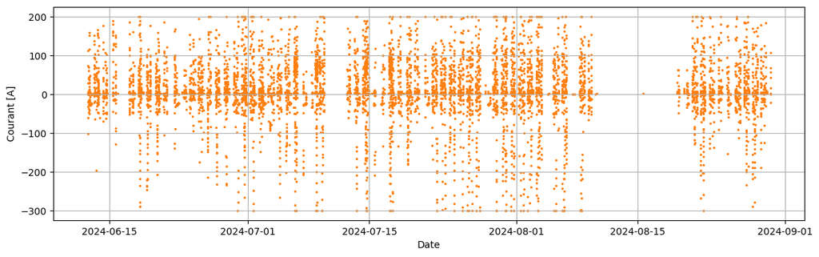

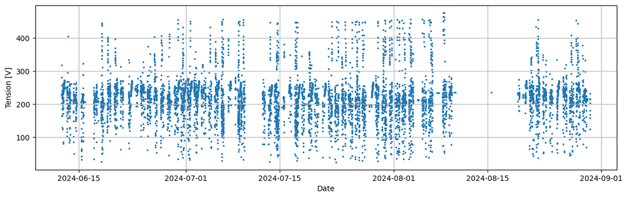

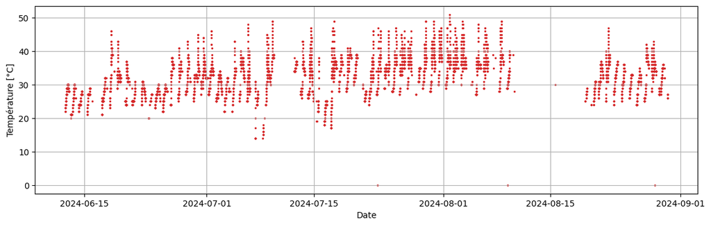

```python
# Visualisation des deux mois de données

view=df.iloc[::200]

plt.figure(figsize=(14,4))
plt.scatter(
    view["date"],
    view["I_A"],
    s=2,
    color=COLOR_I
)
plt.ylabel("Courant [A]")
plt.xlabel("Date")
plt.grid()
plt.show()

plt.figure(figsize=(14,4))
plt.scatter(
    view["date"],
    view["U_V"],
    s=2,
    color=COLOR_U
)
plt.ylabel("Tension [V]")
plt.xlabel("Date")
plt.grid()
plt.show()

plt.figure(figsize=(14,4))
plt.scatter(
    view["date"],
    view["T_C"],
    s=2,
    color=COLOR_T
)
plt.ylabel("Température [°C]")
plt.xlabel("Date")
plt.grid()
plt.show()
```

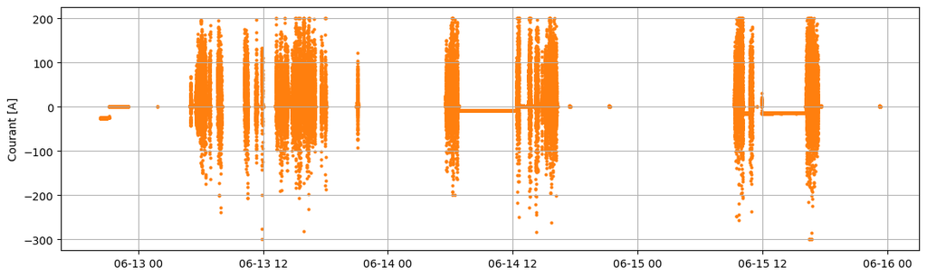

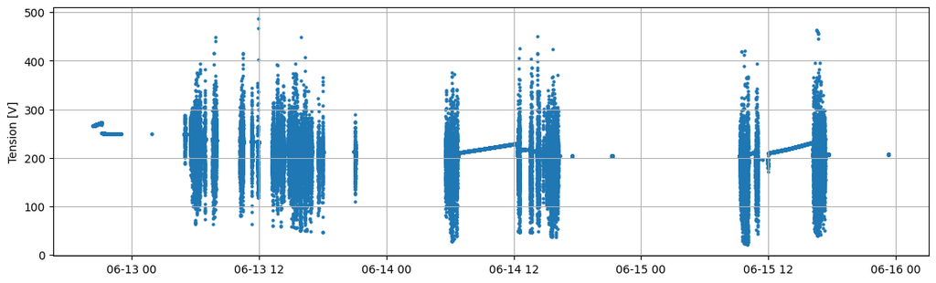

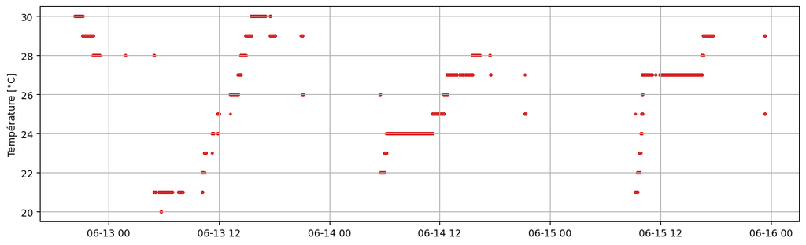

```python
# Zoom entre deux temps

DATE_BEGIN = "2024-06-12 20:20:00"
DATE_END = "2024-06-15 23:40:00"



t0=pd.Timestamp(
  DATE_BEGIN
)

t1=pd.Timestamp(
    DATE_END
)

zoom=df[
    (df["date"]>=t0)
    &(df["date"]<=t1)
]

plt.figure(figsize=(14,4))
plt.scatter(
    zoom["date"],
    zoom["I_A"],
    s=4,
    color=COLOR_I
)
plt.ylabel("Courant [A]")
plt.grid()
plt.show()

plt.figure(figsize=(14,4))
plt.scatter(
    zoom["date"],
    zoom["U_V"],
    s=4,
    color=COLOR_U
)
plt.ylabel("Tension [V]")
plt.grid()
plt.show()

plt.figure(figsize=(14,4))
plt.scatter(
    zoom["date"],
    zoom["T_C"],
    s=4,
    color=COLOR_T
)
plt.ylabel("Température [°C]")
plt.grid()
plt.show()
```

### Questions

- Où voyez-vous des phases de roulage ?
- Où voyez-vous des recharges ?
- Où voyez-vous des périodes de repos ?
- La température évolue-t-elle au cours de la saison ?
- Pourquoi les scatter plots sont-ils plus adaptés ici ?

## Les trous temporels

```python
gaps=df[
    df["delta_s"]>1
]

print(
    "Nombre de trous :",
    len(gaps)
)

gaps[[
    "date",
    "delta_s"
]].head(10)
```

```
Nombre de trous : 1104
```

|  | date | delta_s |
| --- | --- | --- |
| 213 | 2024-06-12 11:23:38 | 57.0 |
| 987 | 2024-06-12 12:08:51 | 1940.0 |
| 1983 | 2024-06-12 12:25:47 | 21.0 |
| 2198 | 2024-06-12 12:46:02 | 1001.0 |
| 3036 | 2024-06-12 13:52:19 | 3140.0 |
| 5466 | 2024-06-12 14:41:41 | 533.0 |
| 14492 | 2024-06-12 17:14:53 | 167.0 |
| 35271 | 2024-06-13 01:51:12 | 10201.0 |
| 35274 | 2024-06-13 04:56:39 | 11125.0 |
| 35935 | 2024-06-13 05:28:32 | 1253.0 |

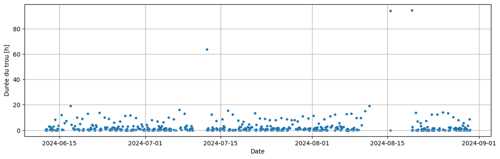

```python
plt.figure(figsize=(14,4))
plt.scatter(
    gaps["date"],
    gaps["delta_s"]/3600,
    s=10
)
plt.ylabel("Durée du trou [h]")
plt.xlabel("Date")
plt.grid()
plt.show()
```

# 3. Calculs de quantités d'interêts

## Calcul de la charge et de l'énergie transférées pendant une recharge

On sélectionne une phase de recharge dans la série temporelle.

Avec la convention utilisée ici :

$$ I<0 \qquad \text{en charge}. $$

La charge électrique transférée pendant la recharge vaut :

$$ \Delta Q = -\int I(t)\,dt $$

et l'énergie transférée au pack :

$$ \Delta E = -\int U(t)I(t)\,dt. $$

En pratique, avec des données discrètes :

$$ \Delta Q \approx -\sum_k I_k\Delta t_k $$

et

$$ \Delta E \approx -\sum_k U_k I_k\Delta t_k. $$

Si une recharge couvre tout l'intervalle

$$ SOC=0\rightarrow SOC=1, $$

alors la charge transférée correspond directement à la capacité du pack :

$$ \boxed{C_{\max}\approx \Delta Q} $$

Pour une recharge partielle, si le SOC initial et final sont connus :

$$ \boxed{ C_{\max} \approx \frac{\Delta Q}{SOC_{\mathrm{fin}}-SOC_{\mathrm{début}}} } $$

Remarque : dans des données d’usage réel, l’estimation de la capacité maximale à partir d’une seule recharge est difficile, car les utilisateurs exploitent rarement toute la plage de SOC. Les recharges commencent souvent avec un SOC encore relativement élevé et s’arrêtent avant 100%, ce qui ne donne accès qu’à une fraction de la capacité totale.

```python
# Zoom sur une charge

DATE_BEGIN = "2024-06-12 17:30:00"
DATE_END = "2024-06-12 21:30:00"

t0=pd.Timestamp(
  DATE_BEGIN
)

t1=pd.Timestamp(
    DATE_END
)

zoom=df[
    (df["date"]>=t0)
    &(df["date"]<=t1)
]
```

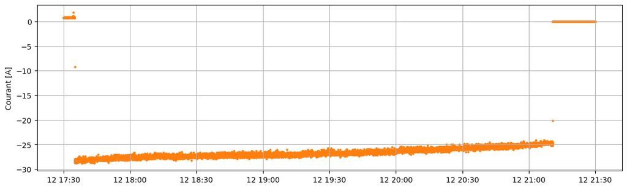

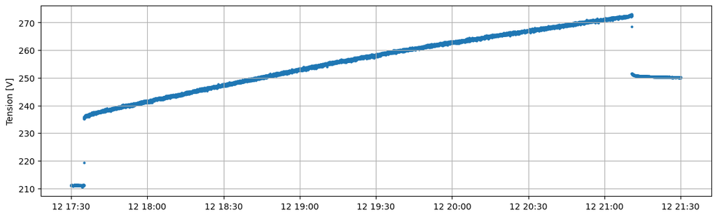

```python
plt.figure(figsize=(14,4))
plt.scatter(zoom["date"],zoom["I_A"],s=4,color=COLOR_I)
plt.ylabel("Courant [A]")
plt.grid()
plt.show()

plt.figure(figsize=(14,4))
plt.scatter(zoom["date"],zoom["U_V"],s=4,color=COLOR_U)
plt.ylabel("Tension [V]")
plt.grid()
plt.show()
```

```python
dt_zoom=zoom["delta_s"].to_numpy()
I_zoom=zoom["I_A"].to_numpy()
U_zoom=zoom["U_V"].to_numpy()

dt_zoom=np.where(
    dt_zoom<=MAX_GAP_S,
    dt_zoom,
    0.0
)

Q_INJECTED=-np.sum(I_zoom*dt_zoom)/3600
E_INJECTED=-np.sum(U_zoom*I_zoom*dt_zoom)/3600/1000

SOC_START=zoom["SOC_true"].iloc[0]
SOC_END=zoom["SOC_true"].iloc[-1]
DELTA_SOC=SOC_END-SOC_START

C_EST=Q_INJECTED/DELTA_SOC

print("SOC début :",SOC_START)
print("SOC fin :",SOC_END)
print("Charge injectée :",Q_INJECTED,"Ah")
print("Énergie injectée :",E_INJECTED,"kWh")
print("Capacité estimée :",C_EST,"Ah")
```

```
SOC début : 0.6169853472222045
SOC fin : 1.0
Charge injectée : 95.75366319444642 Ah
Énergie injectée : 24.48435177898414 kWh
Capacité estimée : 249.9999999999936 Ah
```

Ici, le SOC vrai est utilisé uniquement parce que les données sont synthétiques. Sur des données véhicule réelles, cette information n'est généralement pas connue exactement et devra être estimée en temps réel.

## Bruit et relaxation

Un premier modèle très simple serait :

$$ U=OCV(SOC)-R_0I. $$

Lorsque le courant revient à zéro, ce modèle prédit immédiatement la tension au repos :

$$ U=OCV(SOC). $$

Les données montrent pourtant que la tension peut continuer à évoluer pendant plusieurs minutes.

Cette dynamique lente est la **relaxation**.

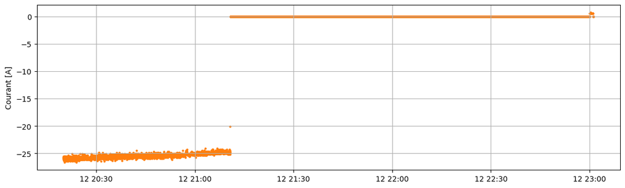

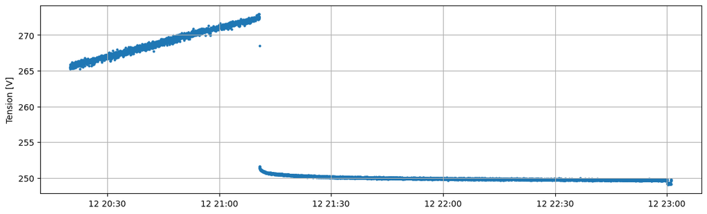

```python
# Zoom sur une relaxation

t0=pd.Timestamp(
    "2024-06-12 20:20:00"
)

t1=pd.Timestamp(
    "2024-06-12 23:40:00"
)

zoom=df[
    (df["date"]>=t0)
    &(df["date"]<=t1)
]

plt.figure(figsize=(14,4))
plt.scatter(
    zoom["date"],
    zoom["I_A"],
    s=4,
    color=COLOR_I
)
plt.ylabel("Courant [A]")
plt.grid()
plt.show()

plt.figure(figsize=(14,4))
plt.scatter(
    zoom["date"],
    zoom["U_V"],
    s=4,
    color=COLOR_U
)
plt.ylabel("Tension [V]")
plt.grid()
plt.show()
```

# 4. Modèles

## Modèle de SOC

Le SOC représente la quantité de charge disponible normalisée par la capacité maximale.

Sous l'hypothèse d'une efficacité coulombique égale à 1 :

$$ \boxed{ \frac{dSOC}{dt} = -\frac{I}{3600C_{\max}} } $$

avec la convention :

$$ I>0 \Rightarrow \text{décharge}. $$

En temps discret, avant saturation :

$$ SOC_{k+1}^{*} = SOC_k - \frac{ I_k\Delta t_k }{ 3600C_{\max} }. $$

Le SOC est une grandeur physique bornée :

$$ 0\le SOC\le1. $$

On impose donc :

$$ \boxed{ SOC_{k+1} = \operatorname{clip} \left( SOC_k - \frac{ I_k\Delta t_k }{ 3600C_{\max} }, 0, 1 \right) } $$

Il faut également connaître l'état initial :

$$ \boxed{ SOC(t=0)=SOC_0 } $$

La trajectoire SOC dépend donc de **deux paramètres inconnus** :

$$ SOC_0 \qquad\text{et}\qquad C_{\max}. $$

On ne calcule pas le SOC avant l'identification : il est simulé en même temps que les états électriques.

### Remarque sur l'autodiff

La fonction `clip` est différentiable tant que le SOC reste strictement dans l'intervalle :

$$ 0<SOC<1. $$

Lorsque le SOC est saturé à 0 ou 1, le gradient dans la direction qui voudrait dépasser la borne devient nul.

C'est ici cohérent avec la contrainte physique du modèle.

## Courbe OCV

OCV pour open circuit voltage correspond à la tension au repos de la batterie. On suppose ici connue la relation :

$$ OCV=OCV(SOC). $$

Dans les données synthétiques, elle est représentée par un polynôme d'ordre 5 :

$$ OCV(SOC) = a_5SOC^5+a_4SOC^4+a_3SOC^3+a_2SOC^2+a_1SOC+a_0. $$

Cette fonction crée le couplage essentiel :

$$ C_{\max},SOC_0 \rightarrow SOC(t) \rightarrow OCV(SOC(t)) \rightarrow U(t). $$

Ainsi, $C_{\max}$ et $SOC_0$ peuvent être identifiés **à partir de la tension**, sans ajouter de loss spécifique sur le SOC.

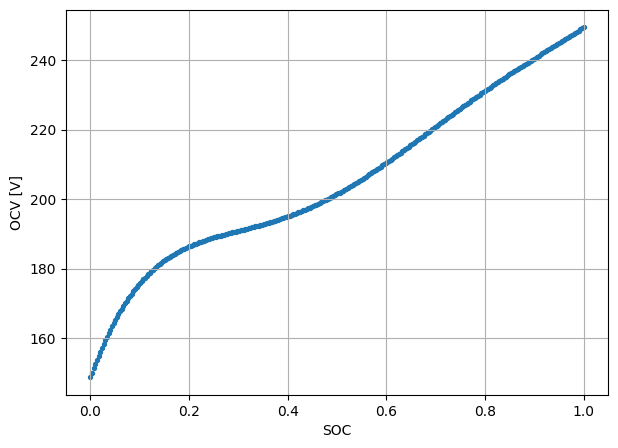

```python
def OCV(soc):
    return jnp.polyval(
        OCV_COEF,
        soc
    )

soc_grid=jnp.linspace(
    0,
    1,
    300
)

plt.figure(figsize=(7,5))
plt.scatter(
    np.array(soc_grid),
    np.array(OCV(soc_grid)),
    s=8
)
plt.xlabel("SOC")
plt.ylabel("OCV [V]")
plt.grid()
plt.show()
```

## Loi vraie de $R_0(SOC,T)$ — référence synthétique

Les données actuelles ont été générer par une loi de résistance connu. On la définit maintenant afin de pouvoir comparer ensuite les fonctions identifiées.

$$ R_0(SOC,T) = R_{0,\min} + A_{SOC}(SOC-0.5)^2 + A_T \frac{ \operatorname{softplus}\left(\frac{25-T}{5}\right) }{ \operatorname{softplus}\left(\frac{25-14}{5}\right) }. $$

Elle sert uniquement de vérité terrain pour l'analyse finale.

```python
R0_MIN_TRUE=0.8
A_SOC_TRUE=0.08
A_TEMP_TRUE=0.15

def R0_true_function(soc,temp):
    num=jax.nn.softplus((25-temp)/5)
    den=jax.nn.softplus((25-14)/5)
    return R0_MIN_TRUE+A_SOC_TRUE*(soc-0.5)**2+A_TEMP_TRUE*num/den

SOC_SURF=jnp.linspace(0.1,1.0,45)
T_SURF=jnp.linspace(10,40,45)
SOC_MESH_TRUE,T_MESH_TRUE=jnp.meshgrid(SOC_SURF,T_SURF)
R0_TRUE_SURF=R0_true_function(SOC_MESH_TRUE,T_MESH_TRUE)
```

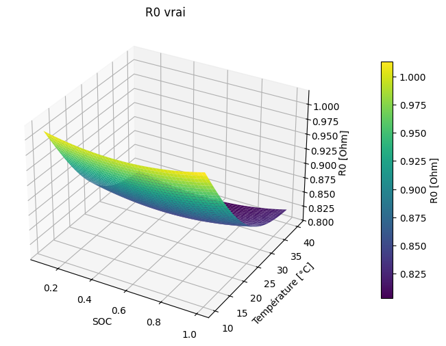

```python
fig=plt.figure(figsize=(9,6))
ax=fig.add_subplot(111,projection="3d")

surf=ax.plot_surface(
    np.array(SOC_MESH_TRUE),
    np.array(T_MESH_TRUE),
    np.array(R0_TRUE_SURF),
    cmap=R0_CMAP,
    linewidth=0
)

ax.set_xlabel("SOC")
ax.set_ylabel("Température [°C]")
ax.set_zlabel("R0 [Ohm]")
ax.set_title("R0 vrai")

cbar=fig.colorbar(surf,ax=ax,pad=0.12,shrink=0.75)
cbar.set_label("R0 [Ohm]")

plt.show()
```

### Question

Les propriétés physiques de la résistance ?

## Modèle électrique équivalent

La tension terminale est modélisée par :

$$ \boxed{ U = OCV(SOC) - R_0(SOC,T)I - \sum_{i=1}^{4}U_i } $$

Les quatre états RC suivent :

$$ \boxed{ \frac{dU_i}{dt} = -\frac{U_i}{\tau_i} + \frac{R_i}{\tau_i}I } $$

avec :

$$ \tau_i=R_iC_i. $$

Pour réduire le nombre de paramètres indépendants, on impose :

$$ \boxed{ \tau_i=\tau_0\,10^i } $$

pour $i=0,1,2,3$ et on suppose l'état initiale $U_i^0 = 0$ pour tout i.

## Discrétisation des états RC

Pendant un pas, on suppose le courant constant.

L'équation :

$$ \frac{dU_i}{dt} = -\frac{U_i}{\tau_i} + \frac{R_i}{\tau_i}I $$

possède alors la solution exacte :

$$ \boxed{ U_i^{k+1} = e^{-\Delta t/\tau_i}U_i^k + \left(1-e^{-\Delta t/\tau_i}\right)R_iI_k } $$

# 5. Identification

## Identification des paramètres du modèle

Certaines grandeurs du modèle sont difficiles, voire impossibles, à mesurer directement sur un pack déjà assemblé.

À l'échelle cellule, certains paramètres électrochimiques ou électriques peuvent être estimés expérimentalement dans des conditions contrôlées. À l'échelle pack, la situation est plus complexe : la tension et le courant sont mesurables, mais des grandeurs comme la capacité effective, les constantes de temps ou les résistances internes ne sont pas directement accessibles.

La résistance observée au niveau du pack ne correspond d'ailleurs pas uniquement à celle des cellules. Elle regroupe également les contributions des connexions électriques, busbars, contacts, câblages et autres éléments du pack.

L'objectif est donc d'identifier ces paramètres à partir des séries temporelles disponibles, en comparant la tension mesurée à la tension prédite par le modèle.

On considère ici une fenêtre de données d'environ **deux semaines**. Les paramètres sont optimisés soit sous forme de **scalaires**, soit, lorsqu'une dépendance plus complexe est nécessaire, sous forme de **fonction paramétrée par un réseau de neurones**.

### Paramètres à identifier

$$ \boxed{ \theta= \left[ SOC_0, C_{\max}, \tau_0, R_1,R_2,R_3,R_4, \theta_{R_0} \right] } $$

Les paramètres

$$ SOC_0,\quad C_{\max},\quad \tau_0,\quad R_1,\ldots,R_4 $$

sont représentés par des scalaires.

La résistance ohmique est représentée par une fonction :

$$ R_0=R_0(SOC,T) $$

paramétrée ici par un petit réseau de neurones.

### Hypothèses

- l'OCV est supposée connue ;
- le SOC initial $SOC_0$ est inconnu ;
- la capacité $C_{\max}$ est inconnue ;
- les quatre états RC sont initialisés à zéro ;
- les paramètres physiques restent positifs :

$$ R_i>0, \qquad \tau_0>0, \qquad C_{\max}>0 ; $$

- le SOC initial est borné :

$$ 0<SOC_0<1 ; $$

- la résistance ohmique est bornée :

$$ 0<R_0(SOC,T)<2\ \Omega. $$

## Fenêtre d'identification

Pour cette première identification, on considère une fenêtre de données d'environ **deux semaines**.

L'objectif est de disposer de suffisamment de sollicitations différentes pour identifier correctement les paramètres électriques, tout en restant sur une durée suffisamment courte pour pouvoir considérer que l'état de santé de la batterie varie peu.

Sur des périodes de plusieurs mois, le vieillissement peut en effet modifier progressivement certains paramètres du modèle, notamment :

$$ C_{\max} $$

et

$$ R_0. $$

On ferait alors l'hypothèse, potentiellement fausse, que des paramètres constants décrivent toute la période.

On cherche donc ici un compromis :

$$ \boxed{ \text{fenêtre assez longue pour identifier} \quad\text{mais assez courte pour négliger le vieillissement} } $$

```python
date_start=pd.Timestamp(
    "2024-06-16 11:19:09"
)

date_end=(
    date_start
    +pd.Timedelta(days=14)
)

train=df[
    (df["date"]>=date_start)
    &(df["date"]<date_end)
].copy()

print(
    "Points bruts :",
    len(train)
)
```

```
Points bruts : 399132
```

```python
# @title
# Réglage utilisé dans cette section
STEP=DOWNSAMPLE_STEP

train=train.iloc[::STEP].copy()
```

```python
I_id=jnp.array(train["I_A"])
T_id=jnp.array(train["T_C"])
U_id=jnp.array(train["U_V"])
time_id=jnp.array(train["time_s"])



dt_real=jnp.concatenate([
    jnp.array([1.0]),
    time_id[1:]-time_id[:-1]
])

GAP_MAX=MAX_GAP_S
is_gap_id=dt_real>GAP_MAX

dt_soc=jnp.where(
    is_gap_id,
    0.0,
    dt_real
)

dt_rc=dt_real

print(
    "Points utilisés :",
    len(I_id)
)

print(
    "Gaps dans la fenêtre :",
    int(jnp.sum(is_gap_id))
)
```

```
Points utilisés : 79827
Gaps dans la fenêtre : 111
```

```python
SOC0_TRUE=float(
    SOC_true[
        train.index[0]
    ]
)

print("SOC0 vrai de la fenêtre :",SOC0_TRUE)
```

```
SOC0 vrai de la fenêtre : 0.5706800902776581
```

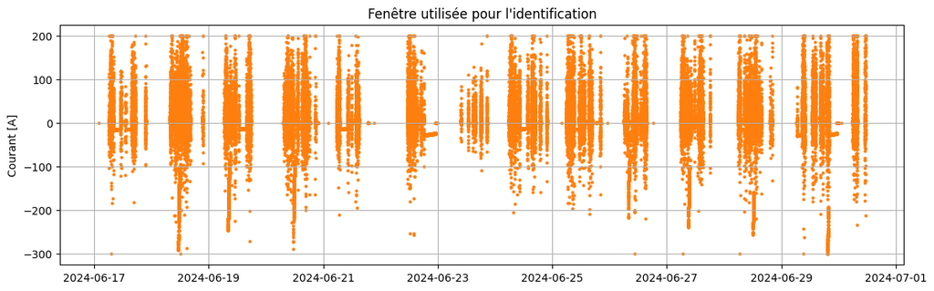

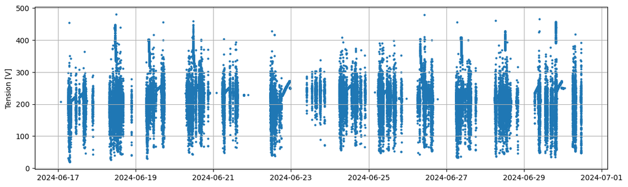

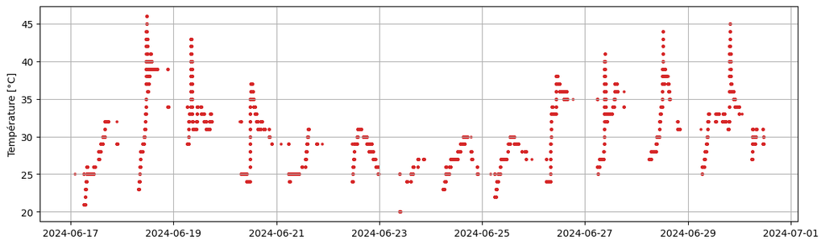

```python
plt.figure(figsize=(14,4))
plt.scatter(
    train["date"],
    train["I_A"],
    s=4,
    color=COLOR_I
)
plt.ylabel("Courant [A]")
plt.title("Fenêtre utilisée pour l'identification")
plt.grid()
plt.show()

plt.figure(figsize=(14,4))
plt.scatter(
    train["date"],
    train["U_V"],
    s=4,
    color=COLOR_U
)
plt.ylabel("Tension [V]")
plt.grid()
plt.show()

plt.figure(figsize=(14,4))
plt.scatter(
    train["date"],
    train["T_C"],
    s=4,
    color=COLOR_T
)
plt.ylabel("Température [°C]")
plt.grid()
plt.show()
```

## Modélisation $R_0(SOC,T)$ sous forme de réseau de neurones

On représente la résistance ohmique par un petit réseau de neurones :

$$ y_\theta = NN_\theta(SOC,T). $$

La sortie brute du réseau n'a pas directement de signification physique.

On applique donc une sigmoïde bornée :

$$ \boxed{ R_0(SOC,T) = R_{0,\max}\, \sigma(y_\theta) } $$

avec ici :

$$ R_{0,\max}=2\ \Omega. $$

On garantit ainsi :

$$ \boxed{ 0<R_0(SOC,T)<2\ \Omega } $$

Le réseau reste volontairement petit : le but n'est pas de construire un modèle profond, mais d'apprendre une fonction effective dépendant du SOC et de la température.

Note sur Equinox : Equinox est une bibliothèque de réseaux de neurones construite au-dessus de JAX. Elle permet de définir des modèles sous forme de classes Python tout en conservant la compatibilité avec l’autodifférentiation, la compilation JIT et les transformations JAX.

```python
# Borne supérieure du réseau R0
R0_MAX=2.0
class R0NN(eqx.Module):
    mlp:eqx.nn.MLP

    def __init__(self,key):
        self.mlp=eqx.nn.MLP(
            in_size=2,
            out_size=1,
            width_size=8,
            depth=1,
            activation=jax.nn.tanh,
            key=key
        )

    def __call__(self,soc,temp):
        x=jnp.array([soc,(temp-25)/10])
        y=self.mlp(x)[0]
        return R0_MAX*jax.nn.sigmoid(y)
```

```python
key=jax.random.PRNGKey(0)
r0_nn=R0NN(key)

N_PARAMS=sum(
    x.size
    for x in jax.tree_util.tree_leaves(
        eqx.filter(r0_nn,eqx.is_array)
    )
)

print("Nombre de paramètres du réseau R0 à optimiser :",N_PARAMS)
```

```
Nombre de paramètres du réseau R0 à optimiser : 33
```

Le réseau représentant $R_0(SOC,T)$ contient seulement 33 paramètres entraînables. Il reste donc volontairement très petit par rapport au nombre de points disponibles pour l'identification.

## Modèle à identifier

```python
class ECM(eqx.Module):
    r0:R0NN
    raw_soc0:jnp.ndarray
    log_Cmax:jnp.ndarray
    log_tau0:jnp.ndarray
    log_R:jnp.ndarray

    def __init__(self,key):
        self.r0=R0NN(key)

        soc0_guess=0.65

        self.raw_soc0=jnp.array(
            jnp.log(
                soc0_guess
                /(1-soc0_guess)
            )
        )

        self.log_Cmax=jnp.array(
            jnp.log(200.0)
        )

        self.log_tau0=jnp.array(
            jnp.log(10.0)
        )

        self.log_R=jnp.log(
            jnp.array([
                0.01,
                0.01,
                0.01,
                0.01
            ])
        )
```

## Transformations des paramètres

Pour imposer automatiquement les contraintes :

$$ SOC_0=\sigma(s_{raw}) $$

avec $\sigma$ la sigmoïde, donc :

$$ 0<SOC_0<1. $$

Et :

$$ C_{\max}=e^{c_{raw}}, \qquad \tau_0=e^{\tau_{raw}}, \qquad R_i=e^{r_i}. $$

Toutes ces grandeurs sont donc positives sans utiliser de clipping après l'optimisation.

## Visualiser le $R_0$ initial

```python
def make_r0_grid(model):
    soc_axis=jnp.linspace(
        0.1,
        1.0,
        45
    )

    temp_axis=jnp.linspace(
        10,
        40,
        45
    )

    SOC_mesh,T_mesh=jnp.meshgrid(
        soc_axis,
        temp_axis
    )

    points=jnp.stack([
        SOC_mesh.ravel(),
        T_mesh.ravel()
    ],axis=1)

    values=jax.vmap(
        lambda x:model.r0(
            x[0],
            x[1]
        )
    )(points)

    R_mesh=values.reshape(
        SOC_mesh.shape
    )

    return (
        SOC_mesh,
        T_mesh,
        R_mesh
    )


def plot_r0_surface(
    model,
    title
):
    SOC_mesh,T_mesh,R_mesh=make_r0_grid(model)

    norm=plt.Normalize(
        float(T_mesh.min()),
        float(T_mesh.max())
    )

    cmap=plt.cm.get_cmap(
        R0_CMAP
    )

    facecolors=cmap(
        norm(
            np.array(T_mesh)
        )
    )

    fig=plt.figure(
        figsize=(9,6)
    )

    ax=fig.add_subplot(
        111,
        projection="3d"
    )

    ax.plot_surface(
        np.array(SOC_mesh),
        np.array(T_mesh),
        np.array(R_mesh),
        facecolors=facecolors,
        linewidth=0,
        antialiased=True,
        shade=False
    )

    ax.set_xlabel("SOC")
    ax.set_ylabel("Température [°C]")
    ax.set_zlabel("R0 [Ohm]")
    ax.set_title(title)

    sm=plt.cm.ScalarMappable(
        norm=norm,
        cmap=cmap
    )

    sm.set_array([])

    cbar=fig.colorbar(
        sm,
        ax=ax,
        pad=0.12,
        shrink=0.75
    )

    cbar.set_label(
        "Température [°C]"
    )

    plt.show()
```

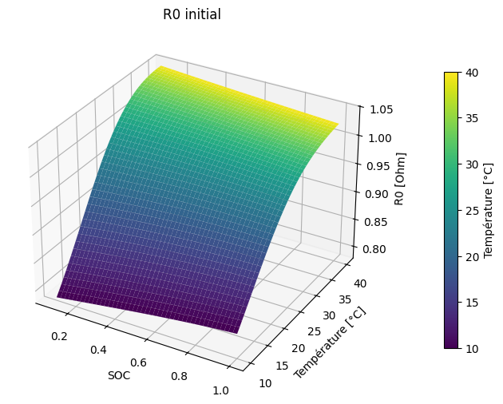

```python
SEED_EXEMPLE = 5
model=ECM(
    jax.random.PRNGKey(SEED_EXEMPLE)
)

plot_r0_surface(
    model,
    "R0 initial"
);
```

Remarque. À ce stade, le réseau n'a encore jamais été entraîné. La surface $R_0(SOC,T)$ affichée provient uniquement de l'initialisation aléatoire de ses poids. Elle n'a donc pas encore de signification physique particulière. En changeant la seed passée à jax.random.PRNGKey(...), on obtient une autre surface initiale.

## Simulation avec une vraie boucle Python

On commence par une implémentation directe des équations avec une boucle `for` Python.

L'état dynamique est :

$$ x_k= \begin{bmatrix} SOC_k\\ U_{1,k}\\ U_{2,k}\\ U_{3,k}\\ U_{4,k} \end{bmatrix}. $$

À chaque pas :

1. on calcule la tension au temps $k$ ;
2. on met à jour le SOC ;
3. on met à jour les quatre états RC.

Cette version est volontairement simple et lisible, mais peu efficace pour de longues séries.

La mise à jour du SOC est ensuite saturée physiquement :

$$ SOC_{k+1} = \operatorname{clip} \left( SOC_k - \frac{ I_k\Delta t_k }{ 3600C_{\max} }, 0, 1 \right). $$

```python
def simulate_python(
    model,
    I,
    T,
    dt_soc,
    dt_rc,
    is_gap
):
    soc=jax.nn.sigmoid(
        model.raw_soc0
    )

    Cmax=jnp.exp(model.log_Cmax)

    tau0=jnp.exp(model.log_tau0)

    tau=tau0*jnp.array([
        1.0,
        10.0,
        100.0,
        1000.0
    ])

    R=jnp.exp(model.log_R)

    Urc=jnp.zeros(4)

    U_pred=[]
    SOC_pred=[]

    for k in range(len(I)):
        r0=model.r0(soc,T[k])

        voltage=(
            OCV(soc)
            -r0*I[k]
            -jnp.sum(Urc)
        )

        U_pred.append(
            voltage
        )

        SOC_pred.append(
            soc
        )

        soc=(
            soc
            -I[k]
            *dt_soc[k]
            /(3600*Cmax)
        )

        soc=jnp.clip(soc,0.0,1.0)

        current_rc=jnp.where(
            is_gap[k],
            0.0,
            I[k]
        )

        alpha=jnp.exp(
            -dt_rc[k]/tau
        )

        Urc=(
            alpha*Urc
            +(1-alpha)
            *R
            *current_rc
        )

    return (
        jnp.stack(U_pred),
        jnp.stack(SOC_pred)
    )
```

## Même simulation avec `jax.lax.scan`

```python
def simulate_scan(
    model,
    I,
    T,
    dt_soc,
    dt_rc,
    is_gap
):
    soc0=jax.nn.sigmoid(model.raw_soc0)

    Cmax=jnp.exp(model.log_Cmax)

    tau0=jnp.exp(model.log_tau0)

    tau=tau0*jnp.array([
        1.0,
        10.0,
        100.0,
        1000.0
    ])

    R=jnp.exp(model.log_R)

    def step(
        state,
        x
    ):
        soc,Urc=state

        (
            current,
            temp,
            delta_soc,
            delta_rc,
            gap
        )=x

        r0=model.r0(soc,temp)

        voltage=(
            OCV(soc)
            -r0*current
            -jnp.sum(Urc)
        )

        soc_new=(
            soc
            -current
            *delta_soc
            /(3600*Cmax)
        )

        soc_new=jnp.clip(soc_new,0.0,1.0)

        current_rc=jnp.where(
            gap,
            0.0,
            current
        )

        alpha=jnp.exp(
            -delta_rc/tau
        )

        Urc_new=(
            alpha*Urc
            +(1-alpha)
            *R
            *current_rc
        )

        new_state=(
            soc_new,
            Urc_new
        )

        output=(
            voltage,
            soc
        )

        return (
            new_state,
            output
        )

    state0=(
        soc0,
        jnp.zeros(4)
    )

    _,outputs=jax.lax.scan(
        step,
        state0,
        (
            I,
            T,
            dt_soc,
            dt_rc,
            is_gap
        )
    )

    U_pred,SOC_pred=outputs

    return (
        U_pred,
        SOC_pred
    )
```

`lax.scan` représente la boucle temporelle comme une primitive JAX.

Cela permet notamment :

- l'autodiff à travers toute la trajectoire ;
- la compilation XLA ;
- une exécution beaucoup plus efficace qu'une longue boucle Python.

## Loss unique sur la tension

### Fonction de coût

L'identification consiste à ajuster les paramètres du modèle afin que la tension simulée soit la plus proche possible de la tension mesurée.

Pour mesurer l'écart entre les deux, on introduit une **fonction de coût** (ou *loss*) :

$$ \mathcal L(\theta) $$

Cette quantité dépend des paramètres à identifier :

$$ \theta= \left[ SOC_0, C_{\max}, \tau_0, R_1,\ldots,R_4, \theta_{R_0} \right]. $$

Plus la loss est faible, plus le modèle reproduit correctement la tension mesurée.

On choisit ici l'erreur quadratique moyenne (MSE) :

$$ \boxed{ \mathcal L(\theta) = \frac1N \sum_{k=1}^N \left( U_k^{pred}(\theta) - U_k^{mes} \right)^2 } $$

L'optimisation consiste donc à chercher :

$$ \boxed{ \theta^\star = \arg\min_\theta \mathcal L(\theta) } $$

La loss porte uniquement sur la tension, mais cela ne signifie pas que seuls les paramètres électriques sont appris.

En effet, la tension prédite dépend du SOC simulé :

$$ U^{pred} = OCV(SOC^{pred}) - R_0(SOC^{pred},T)I - \sum_i U_i. $$

Or le SOC simulé dépend notamment de :

$$ SOC_0 \qquad\text{et}\qquad C_{\max}. $$

On a donc la chaîne de dépendance :

$$ \boxed{ SOC_0,C_{\max} \rightarrow SOC(t) \rightarrow OCV(SOC) \rightarrow U(t) \rightarrow \mathcal L } $$

Ainsi, même sans utiliser directement une erreur sur le SOC, la loss en tension contient de l'information sur $SOC_0$ et $C_{\max}$.

```python
def loss(model):
    U_pred,_=simulate_scan(
        model,
        I_id,
        T_id,
        dt_soc,
        dt_rc,
        is_gap_id
    )

    return jnp.mean(
        (U_pred-U_id)**2
    )
```

```python
def r2_score(
    y_true,
    y_pred
):
    ss_res=jnp.sum(
        (y_true-y_pred)**2
    )

    ss_tot=jnp.sum(
        (
            y_true-jnp.mean(y_true)
        )**2
    )

    return (
        1
        -ss_res/ss_tot
    )
```

## Boucle Python, `scan` et compilation JIT

Le modèle dynamique doit être propagé sur toute la série temporelle, point après point.

Une première approche consiste à utiliser une **boucle Python classique**. Elle est simple à lire, mais peut devenir coûteuse lorsque la série contient beaucoup de points et que la simulation doit être répétée de nombreuses fois pendant l'optimisation.

On compare donc trois approches :

- une boucle Python classique ;
- `jax.lax.scan`, qui permet de représenter efficacement une dynamique séquentielle dans JAX ;
- la même simulation compilée avec JIT.

L'objectif est de comparer leur temps de calcul pour une même propagation du modèle.

Cette différence devient importante lors de l'identification : une optimisation peut nécessiter plusieurs centaines ou milliers d'itérations, et donc autant de simulations du modèle.

### Boucle classique Python

On utilise le même nombre de points pour toutes les mesures de temps.

Le réglage global est rappelé ici :

```
N_TEST=N_TEST_SPEED
```

```python
N_TEST_SPEED = 5000
N_TEST=N_TEST_SPEED

t0=time.perf_counter()

U_python,SOC_python=simulate_python(
    model,
    I_id[:N_TEST],
    T_id[:N_TEST],
    dt_soc[:N_TEST],
    dt_rc[:N_TEST],
    is_gap_id[:N_TEST]
)

jax.block_until_ready(U_python)
TIME_PYTHON=time.perf_counter()-t0

print("Nombre de points :",N_TEST)
print("Temps boucle Python :",TIME_PYTHON,"s")
```

```
Nombre de points : 5000
Temps boucle Python : 32.37184886199975 s
```

### Boucle avec `lax.scan` compilé avec JAX

Le modèle Equinox contient des tableaux entraînables mais aussi des objets statiques comme la fonction d'activation.

```python
simulate_jit=eqx.filter_jit(simulate_scan)

t0=time.perf_counter()

U_jit,SOC_jit=simulate_jit(
    model,
    I_id[:N_TEST],
    T_id[:N_TEST],
    dt_soc[:N_TEST],
    dt_rc[:N_TEST],
    is_gap_id[:N_TEST]
)

jax.block_until_ready(U_jit)
TIME_JIT_FIRST=time.perf_counter()-t0

print("Premier appel JIT :",TIME_JIT_FIRST,"s")
```

```
Premier appel JIT : 0.4046348890005902 s
```

```python
t0=time.perf_counter()

U_jit,SOC_jit=simulate_jit(
    model,
    I_id[:N_TEST],
    T_id[:N_TEST],
    dt_soc[:N_TEST],
    dt_rc[:N_TEST],
    is_gap_id[:N_TEST]
)

jax.block_until_ready(U_jit)
TIME_JAX=time.perf_counter()-t0

SPEEDUP=TIME_PYTHON/TIME_JAX

print("Deuxième appel JAX compilé :",TIME_JAX,"s")
print("Rapport temps Python / temps JAX :",SPEEDUP)
```

[output not shown]

### Question — coût d'une optimisation

Le rapport mesuré est :

$$ \text{accélération}=\frac{t_{Python}}{t_{JAX}}. $$

Le temps mesuré correspond à une propagation du modèle. Une optimisation en demande des centaines ou milliers. Or, pendant l’optimisation, cette simulation est répétée à chaque itération. En supposant 1000 itérations, estimez le temps total avec la boucle Python puis avec JAX compilé. Que concluez-vous sur l’intérêt de la compilation pour un problème d’identification ?

### À retenir

Une fonction utilisant `lax.scan` n'est pas la même chose qu'une boucle Python.

Mais `scan` est déjà une primitive JAX conçue pour être tracée et compilée.

# 6. Entraînement

```python
LEARNING_RATE = 1e-2
LR=LEARNING_RATE
optimizer=optax.adam(LR)

opt_state=optimizer.init(
    eqx.filter(
        model,
        eqx.is_array
    )
)

@eqx.filter_jit
def train_step(
    model,
    opt_state
):
    value,grads=(
        eqx.filter_value_and_grad(
            loss
        )(model)
    )

    updates,opt_state=(
        optimizer.update(
            grads,
            opt_state,
            model
        )
    )

    model=eqx.apply_updates(
        model,
        updates
    )

    return (
        model,
        opt_state,
        value
    )
```

### Évolution de $R_0(SOC,T)$ pendant l'optimisation

```
epoch 30 / 300
loss = 1.3605032067269653
R² = 0.9994192473670886
SOC0 = 0.5863798108860595
Cmax = 260.18725055174383 Ah
```

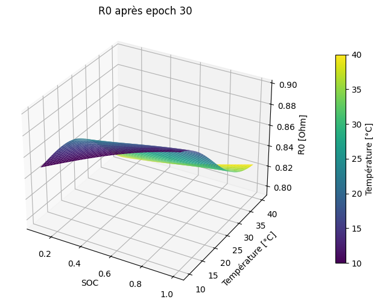

```
epoch 40 loss 1.3384813258837225 R² 0.9994292901984525
epoch 50 loss 1.3549888842011932 R² 0.9994251495868423
epoch 60 loss 1.3599421413696748 R² 0.9994279329860015
epoch 70 loss 1.3313167229146319 R² 0.9994188217234775
epoch 80 loss 1.3518330486336407 R² 0.9994201496388839
epoch 90 loss 1.3611196960605247 R² 0.9994288826959119
epoch 100 loss 1.3440493094466712 R² 0.9994299759210432
epoch 110 loss 1.336415406792924 R² 0.9994231653583138
epoch 120 loss 1.350956138597481 R² 0.9994210552430651
epoch 130 loss 1.3567356461942572 R² 0.9994229659740345
epoch 140 loss 1.3528265870303098 R² 0.9994284366255946
epoch 150 loss 1.3393858859388763 R² 0.9994364507900764
epoch 160 loss 1.3207058824355928 R² 0.9994202746283938
epoch 170 loss 1.3597710201564157 R² 0.9994156382339487
epoch 180 loss 1.370809588310804 R² 0.9994265162873622
epoch 190 loss 1.3448768764782986 R² 0.9994334727745992
epoch 200 loss 1.328071494229025 R² 0.9994258794977318
epoch 210 loss 1.3461239506478835 R² 0.9994226634292961
epoch 220 loss 1.3537942471156745 R² 0.9994244196532233
epoch 230 loss 1.349658897504098 R² 0.9994303812151571
epoch 240 loss 1.3355802296585697 R² 0.9994388092035519
epoch 250 loss 1.3156830850480141 R² 0.9994192646473353
epoch 260 loss 1.3619897760218562 R² 0.9994142865877146
epoch 270 loss 1.3737437600033195 R² 0.999426360614449
```

[output not shown]

```python
from IPython.display import clear_output

history=[]
r2_history=[]
# Réglages utilisés pour cet entraînement
N_EPOCHS=300
DISPLAY_EVERY=DISPLAY_R0_EVERY
DISPLAY_UNTIL=DISPLAY_R0_UNTIL
PRINT_EVERY=10
PRINT_STEP=PRINT_EVERY
DISPLAY_R0_EVERY=2
DISPLAY_R0_UNTIL=30


for epoch in range(
    N_EPOCHS
):
    model,opt_state,value=train_step(
        model,
        opt_state
    )

    history.append(
        float(value)
    )

    if (
        epoch%DISPLAY_EVERY==0
        and epoch<=DISPLAY_UNTIL
    ):
        U_epoch,_=simulate_scan(
            model,
            I_id,
            T_id,
            dt_soc,
            dt_rc,
            is_gap_id
        )

        r2_epoch=float(
            r2_score(
                U_id,
                U_epoch
            )
        )

        r2_history.append(
            [
                epoch,
                r2_epoch
            ]
        )

        clear_output(
            wait=True
        )

        soc0_now=float(
            jax.nn.sigmoid(
                model.raw_soc0
            )
        )

        cmax_now=float(
            jnp.exp(
                model.log_Cmax
            )
        )

        print(
            "epoch",
            epoch,
            "/",
            N_EPOCHS
        )

        print(
            "loss =",
            float(value)
        )

        print(
            "R² =",
            r2_epoch
        )

        print(
            "SOC0 =",
            soc0_now
        )

        print(
            "Cmax =",
            cmax_now,
            "Ah"
        )

        plot_r0_surface(
            model,
            "R0 après epoch "
            +str(epoch)
        )

    elif epoch%PRINT_STEP==0:
        U_epoch,_=simulate_scan(
            model,
            I_id,
            T_id,
            dt_soc,
            dt_rc,
            is_gap_id
        )

        r2_epoch=float(
            r2_score(
                U_id,
                U_epoch
            )
        )

        r2_history.append(
            [
                epoch,
                r2_epoch
            ]
        )

        print(
            "epoch",
            epoch,
            "loss",
            float(value),
            "R²",
            r2_epoch
        )
```

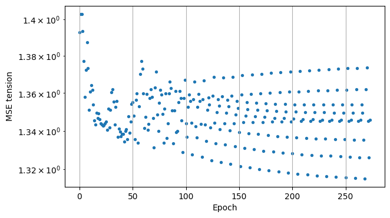

```python
plt.figure(figsize=(7,4))
plt.scatter(
    np.arange(len(history)),
    history,
    s=8,
    color=COLOR_U
)
plt.yscale("log")
plt.xlabel("Epoch")
plt.ylabel("MSE tension")
plt.grid()
plt.show()
```

Discussion sur la valeur de la loss ?

### Suivi du coefficient $R^2$

En complément de la MSE, on suit :

$$ R^2 = 1- \frac{ \sum_k \left( U_k^{mes}-U_k^{pred} \right)^2 }{ \sum_k \left( U_k^{mes}-\overline U^{mes} \right)^2 }. $$

Un $R^2$ proche de 1 signifie que le modèle reproduit une grande partie de la variabilité de la tension mesurée.

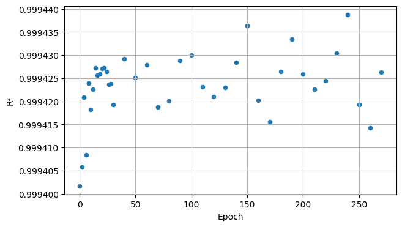

```python
r2_history=np.array(
    r2_history
)

plt.figure(figsize=(7,4))

plt.scatter(
    r2_history[:,0],
    r2_history[:,1],
    s=20,
    color=COLOR_U
)

plt.xlabel("Epoch")
plt.ylabel("R²")
plt.grid()
plt.show()
```

## Comparaison visuelle de la tension

```
R² tension global : 0.9994226278948738
```

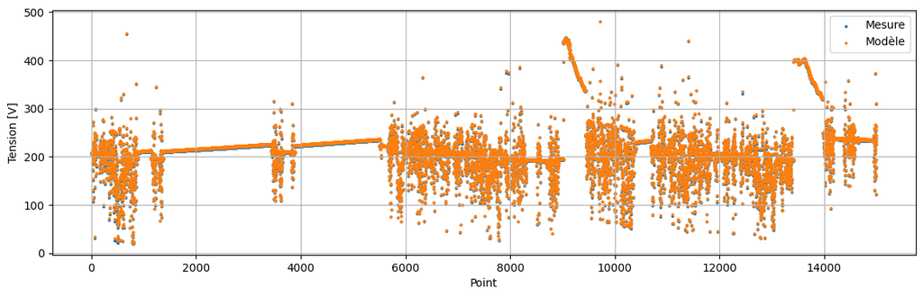

```python
U_pred,SOC_pred=simulate_scan(
    model,
    I_id,
    T_id,
    dt_soc,
    dt_rc,
    is_gap_id
)

R2_voltage=float(
    r2_score(
        U_id,
        U_pred
    )
)

print(
    "R² tension global :",
    R2_voltage
)

n=15000

plt.figure(figsize=(14,4))
plt.scatter(
    np.arange(n),
    np.array(U_id[:n]),
    s=3,
    color=COLOR_U,
    label="Mesure"
)
plt.scatter(
    np.arange(n),
    np.array(U_pred[:n]),
    s=3,
    color=COLOR_I,
    label="Modèle"
)
plt.ylabel("Tension [V]")
plt.xlabel("Point")
plt.legend()
plt.grid()
plt.show()
```

### Zoom local sur la tension prédite

La vue globale permet de vérifier le comportement sur une longue durée, mais elle masque les détails.

On zoome ici sur une courte fenêtre pour vérifier si le modèle reproduit :

- les variations rapides liées au courant ;
- les phases de relaxation ;
- les petits écarts de tension.

[figure not shown]

```
R² sur le zoom : 0.9999923112779797
```

```python
ZOOM_END=ZOOM_START+ZOOM_LENGTH
x_zoom=np.arange(ZOOM_START,ZOOM_END)



plt.figure(figsize=(14,5))

plt.scatter(
    x_zoom,
    np.array(
        U_id[ZOOM_START:ZOOM_END]
    ),
    s=8,
    color=COLOR_U,
    label="Mesure"
)

plt.scatter(
    x_zoom,
    np.array(
        U_pred[ZOOM_START:ZOOM_END]
    ),
    s=8,
    color=COLOR_I,
    label="Prédiction"
)

plt.xlabel("Point")
plt.ylabel("Tension [V]")
plt.title(
    "Zoom mesure vs prédiction"
)

plt.legend()
plt.grid()
plt.show()

R2_zoom=float(
    r2_score(
        U_id[ZOOM_START:ZOOM_END],
        U_pred[ZOOM_START:ZOOM_END]
    )
)

print(
    "R² sur le zoom :",
    R2_zoom
)
```

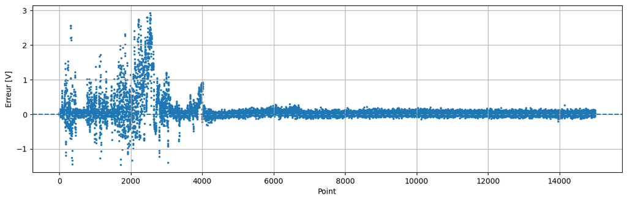

```python
error=(
    U_pred-U_id
)

plt.figure(figsize=(14,4))
plt.scatter(
    np.arange(n),
    np.array(error[:n]),
    s=3
)
plt.axhline(
    0,
    linestyle="--"
)
plt.ylabel("Erreur [V]")
plt.xlabel("Point")
plt.grid()
plt.show()
```

## Analyse statistique des résidus

On définit le résidu :

$$ \varepsilon_k = U_k^{pred} - U_k^{mes}. $$

Si le modèle capture correctement la dynamique moyenne, on souhaite idéalement :

$$ \mathbb E[\varepsilon]\approx0. $$

On regarde également l'écart-type :

$$ \sigma_\varepsilon = \sqrt{ \mathbb E[ (\varepsilon-\bar\varepsilon)^2 ] }. $$

Comme le jeu synthétique contient un bruit de tension connu, on pourra comparer l'écart-type des résidus au niveau de bruit injecté.

```python
residual=np.array(
    U_pred-U_id
)

res_mean=float(
    np.mean(residual)
)

res_std=float(
    np.std(residual)
)

res_rmse=float(
    np.sqrt(
        np.mean(
            residual**2
        )
    )
)

print(
    "Moyenne résidu :",
    res_mean,
    "V"
)

print(
    "Écart-type résidu :",
    res_std,
    "V"
)

print(
    "RMSE :",
    res_rmse,
    "V"
)

print(
    "Bruit injecté :",
    VOLTAGE_NOISE_STD,
    "V"
)


R2_global=float(
    r2_score(
        U_id,
        U_pred
    )
)

print(
    "R² global :",
    R2_global
)
```

[output not shown]

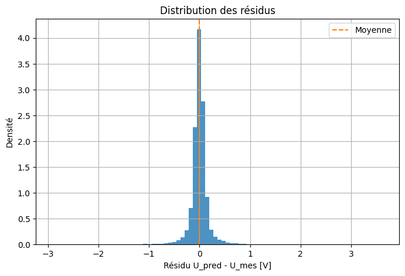

```python
plt.figure(figsize=(8,5))

plt.hist(
    residual,
    bins=80,
    density=True,
    alpha=0.8,
    color=COLOR_U
)

plt.axvline(
    res_mean,
    linestyle="--",
    color=COLOR_I,
    label="Moyenne"
)

plt.xlabel("Résidu U_pred - U_mes [V]")
plt.ylabel("Densité")
plt.title("Distribution des résidus")
plt.legend()
plt.grid()
plt.show()
```

## Paramètres identifiés

```python
SOC0_id=jax.nn.sigmoid(
    model.raw_soc0
)

Cmax_id=jnp.exp(
    model.log_Cmax
)

tau0_id=jnp.exp(
    model.log_tau0
)

tau_id=(
    tau0_id
    *jnp.array([
        1.0,
        10.0,
        100.0,
        1000.0
    ])
)

R_id=jnp.exp(
    model.log_R
)

print(
    "SOC0 identifié :",
    float(SOC0_id)
)

print(
    "Cmax identifié :",
    float(Cmax_id),
    "Ah"
)

print(
    "tau0 identifié :",
    float(tau0_id),
    "s"
)

print(
    "tau identifiés :",
    tau_id
)

print(
    "R identifiés :",
    R_id
)
```

```
SOC0 identifié : 0.5708036572996819
Cmax identifié : 250.19630426636047 Ah
tau0 identifié : 5.795476355913769 s
tau identifiés : [   5.79547636   57.95476356  579.54763559 5795.47635591]
R identifiés : [0.01510087 0.0191348  0.02758673 0.0276821 ]
```

## Validation de la calibration

On compare :

- les paramètres identifiés aux vraies valeurs ;
- le SOC prédit au SOC vrai ;
- la fonction $R_0(SOC,T)$ prédite à la vraie fonction.

```python
PACK_SINGLE=pd.DataFrame({
    "Grandeur":[
        "SOC0","Cmax [Ah]","tau0 [s]",
        "R1 [Ohm]","R2 [Ohm]","R3 [Ohm]","R4 [Ohm]"
    ],
    "Vrai":[
        SOC0_TRUE,C_MAX_TRUE,TAU0_TRUE,
        float(R_RC_TRUE[0]),float(R_RC_TRUE[1]),
        float(R_RC_TRUE[2]),float(R_RC_TRUE[3])
    ],
    "Prédit":[
        float(SOC0_id),float(Cmax_id),float(tau0_id),
        float(R_id[0]),float(R_id[1]),
        float(R_id[2]),float(R_id[3])
    ]
})

PACK_SINGLE["Erreur relative [%]"]=100*np.abs(
    PACK_SINGLE["Prédit"]-PACK_SINGLE["Vrai"]
)/np.maximum(np.abs(PACK_SINGLE["Vrai"]),1e-12)

PACK_SINGLE
```

|  | Grandeur | Vrai | Prédit | Erreur relative [%] |
| --- | --- | --- | --- | --- |
| 0 | SOC0 | 0.57068 | 0.570804 | 0.021653 |
| 1 | Cmax [Ah] | 250.00000 | 250.196304 | 0.078522 |
| 2 | tau0 [s] | 5.00000 | 5.795476 | 15.909527 |
| 3 | R1 [Ohm] | 0.01500 | 0.015101 | 0.672444 |
| 4 | R2 [Ohm] | 0.02000 | 0.019135 | 4.326001 |
| 5 | R3 [Ohm] | 0.02500 | 0.027587 | 10.346914 |
| 6 | R4 [Ohm] | 0.03000 | 0.027682 | 7.726338 |

Une très bonne prédiction de la tension ne garantit pas que les paramètres identifiés soient physiquement corrects. Plusieurs combinaisons de paramètres peuvent parfois produire des tensions très proches : $$ \boxed{ U^{pred}\approx U^{mes} } $$ tout en donnant des valeurs différentes de $$ SOC_0,\quad C_{\max},\quad \tau_i,\quad R_i,\quad R_0. $$ Le modèle peut donc être très bon en prédiction, mais moins fiable pour l'interprétation physique des paramètres. C'est précisément ce qu'on appelle un problème d'identifiabilité : les données observées ne permettent pas toujours de déterminer de manière unique tous les paramètres internes du modèle.

### $R_0$ vrai vs prédit

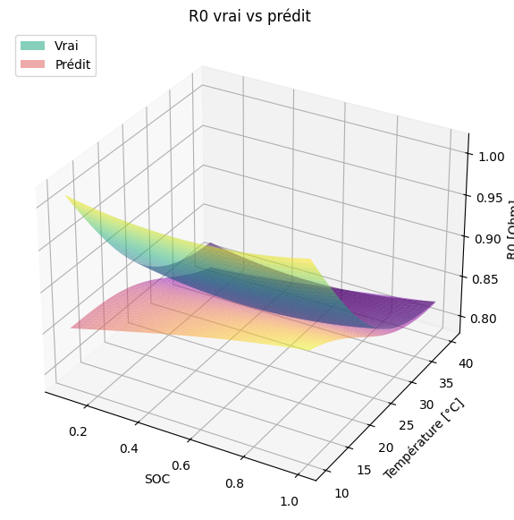

```
MAE surface R0 : 0.028309311435264085 Ohm
RMSE surface R0 : 0.045017548029240795 Ohm
```

```python
from matplotlib.patches import Patch

SOC_MESH,T_MESH,R0_SINGLE=make_r0_grid(model)
R0_REF=R0_true_function(SOC_MESH,T_MESH)

fig=plt.figure(figsize=(10,7))
ax=fig.add_subplot(111,projection="3d")

ax.plot_surface(
    np.array(SOC_MESH),np.array(T_MESH),np.array(R0_REF),
    cmap="viridis",alpha=0.55,linewidth=0
)

ax.plot_surface(
    np.array(SOC_MESH),np.array(T_MESH),np.array(R0_SINGLE),
    cmap="plasma",alpha=0.55,linewidth=0
)

ax.set_xlabel("SOC")
ax.set_ylabel("Température [°C]")
ax.set_zlabel("R0 [Ohm]")
ax.set_title("R0 vrai vs prédit")

legend_handles=[
    Patch(facecolor=plt.cm.viridis(0.6),alpha=0.55,label="Vrai"),
    Patch(facecolor=plt.cm.plasma(0.6),alpha=0.55,label="Prédit")
]
ax.legend(handles=legend_handles,loc="upper left")

plt.show()

R0_ERR_SINGLE=R0_SINGLE-R0_REF

print("MAE surface R0 :",float(jnp.mean(jnp.abs(R0_ERR_SINGLE))),"Ohm")
print("RMSE surface R0 :",float(jnp.sqrt(jnp.mean(R0_ERR_SINGLE**2))),"Ohm")
```

## Vérification du SOC — seulement après l'identification

On peut maintenant le comparer à la trajectoire reconstruite pour vérifier si l'identification de $SOC_0$ et $C_{\max}$ est cohérente.

[figure not shown]

[output not shown]

```python
SOC_TRUE_SINGLE=SOC_true[train.index.to_numpy()]
SOC_ERROR_SINGLE=np.array(SOC_pred-SOC_TRUE_SINGLE)

SOC_MAE_SINGLE=float(np.mean(np.abs(SOC_ERROR_SINGLE)))
SOC_RMSE_SINGLE=float(np.sqrt(np.mean(SOC_ERROR_SINGLE**2)))

plt.figure(figsize=(14,5))
plt.scatter(np.arange(len(SOC_TRUE_SINGLE)),np.array(SOC_TRUE_SINGLE),
            s=3,color=COLOR_SOC,label="SOC vrai")
plt.scatter(np.arange(len(SOC_pred)),np.array(SOC_pred),
            s=3,color="purple",label="SOC prédit")

plt.ylim(-0.02,1.02)
plt.xlabel("Point")
plt.ylabel("SOC")
plt.title("SOC vrai vs SOC prédit")
plt.legend()
plt.grid()
plt.show()

print("MAE SOC :",SOC_MAE_SINGLE)
print("RMSE SOC :",SOC_RMSE_SINGLE)
```

Le SOC reconstruit suit globalement correctement le SOC vrai, mais on observe un décalage progressif sur certaines portions de la trajectoire, notamment vers la fin. Avec un seul $SOC_0$, l'optimisation cherche en quelque sorte un état initial global qui convient au mieux à toute la fenêtre. Or, comme le SOC est obtenu par intégration du courant, $$ SOC(t) = SOC_0 - \frac{1}{3600C_{\max}} \int I(t)\,dt, $$ une petite erreur sur $SOC_0$, $C_{\max}$ ou sur le modèle peut s'accumuler progressivement et produire un drift du SOC. Sur une trajectoire longue, il peut donc être pertinent de recaler périodiquement le SOC plutôt que d'utiliser un unique $SOC_0$ pour toute la fenêtre.

# 7. Entrainement en multiple shooting

Le SOC reconstruit suit correctement la tendance générale, mais on observe progressivement un **décalage**.

Ce phénomène vient du fait que le SOC est obtenu par intégration :

$$ SOC_k = SOC_0 - \frac{1}{3600C_{\max}} \sum_{j=0}^{k-1} I_j\Delta t_j. $$

Une petite erreur sur :

$$ SOC_0 $$

ou sur :

$$ C_{\max} $$

peut donc s'accumuler au cours du temps.

On va maintenant corriger ce drift en introduisant un deuxième état initial de SOC au milieu de la trajectoire.

## Principe du double shooting

On coupe la série en deux fenêtres :

$$ [0,t_m] \qquad\text{et}\qquad [t_m,t_f]. $$

On introduit deux états initiaux :

$$ SOC_0^{(1)} \qquad\text{et}\qquad SOC_0^{(2)}. $$

Tous les autres paramètres restent globaux :

$$ C_{\max}, \quad \tau_0, \quad R_1,\ldots,R_4, \quad R_0(SOC,T). $$

La première fenêtre part de :

$$ SOC(0)=SOC_0^{(1)} $$

et la seconde de :

$$ SOC(t_m)=SOC_0^{(2)}. $$

```python
CUT=50_000

I_1=I_id[:CUT]
T_1=T_id[:CUT]
U_1=U_id[:CUT]
dt_soc_1=dt_soc[:CUT]
dt_rc_1=dt_rc[:CUT]
gap_1=is_gap_id[:CUT]

I_2=I_id[CUT:]
T_2=T_id[CUT:]
U_2=U_id[CUT:]
dt_soc_2=dt_soc[CUT:]
dt_rc_2=dt_rc[CUT:]
gap_2=is_gap_id[CUT:]

print(
    "Points fenêtre 1 :",
    len(I_1)
)

print(
    "Points fenêtre 2 :",
    len(I_2)
)
```

```
Points fenêtre 1 : 50000
Points fenêtre 2 : 29827
```

## Modèle à deux $SOC_0$

On apprend maintenant :

$$ \theta= \left[ SOC_0^{(1)}, SOC_0^{(2)}, C_{\max}, \tau_0, R_1,\ldots,R_4, \theta_{R_0} \right]. $$

Les deux SOC initiaux sont paramétrés par des sigmoïdes pour garantir :

$$ 0<SOC_0^{(1)}<1 $$

et :

$$ 0<SOC_0^{(2)}<1. $$

```python
class ECM2Shoot(eqx.Module):
    r0:R0NN
    raw_soc01:jnp.ndarray
    raw_soc02:jnp.ndarray
    log_Cmax:jnp.ndarray
    log_tau0:jnp.ndarray
    log_R:jnp.ndarray

    def __init__(
        self,
        key
    ):
        self.r0=R0NN(
            key
        )

        soc01_guess=0.65
        soc02_guess=0.65

        self.raw_soc01=jnp.array(
            jnp.log(
                soc01_guess
                /(1-soc01_guess)
            )
        )

        self.raw_soc02=jnp.array(
            jnp.log(
                soc02_guess
                /(1-soc02_guess)
            )
        )

        self.log_Cmax=jnp.array(
            jnp.log(
                200.0
            )
        )

        self.log_tau0=jnp.array(
            jnp.log(
                10.0
            )
        )

        self.log_R=jnp.log(
            jnp.array([
                0.01,
                0.01,
                0.01,
                0.01
            ])
        )
```

```python
def simulate_window(
    model,
    raw_soc0,
    I,
    T,
    dt_soc,
    dt_rc,
    is_gap
):
    soc0=jax.nn.sigmoid(raw_soc0)

    Cmax=jnp.exp(model.log_Cmax)

    tau0=jnp.exp(model.log_tau0)

    tau=tau0*jnp.array([
        1.0,
        10.0,
        100.0,
        1000.0
    ])

    R=jnp.exp(model.log_R)

    def step(
        state,
        x
    ):
        soc,Urc=state

        (
            current,
            temp,
            delta_soc,
            delta_rc,
            gap
        )=x

        r0=model.r0(soc,temp)

        voltage=(
            OCV(soc)
            -r0*current
            -jnp.sum(Urc)
        )

        soc_new=(
            soc
            -current
            *delta_soc
            /(3600*Cmax)
        )

        soc_new=jnp.clip(soc_new,0.0,1.0)

        current_rc=jnp.where(
            gap,
            0.0,
            current
        )

        alpha=jnp.exp(
            -delta_rc/tau
        )

        Urc_new=(
            alpha*Urc
            +(1-alpha)
            *R
            *current_rc
        )

        return (
            (
                soc_new,
                Urc_new
            ),
            (
                voltage,
                soc
            )
        )

    state0=(
        soc0,
        jnp.zeros(4)
    )

    final_state,outputs=jax.lax.scan(
        step,
        state0,
        (
            I,
            T,
            dt_soc,
            dt_rc,
            is_gap
        )
    )

    U_pred,SOC_pred=outputs

    soc_end=final_state[0]

    return (
        U_pred,
        SOC_pred,
        soc_end
    )
```

## Régularisation de continuité

Si les deux SOC initiaux sont totalement indépendants, le second peut absorber artificiellement une partie de l'erreur du modèle.

On ajoute donc :

$$ \mathcal L_{\mathrm{cont}} = \left( SOC_{\mathrm{fin}}^{(1)} - SOC_0^{(2)} \right)^2. $$

La loss totale devient :

$$ \boxed{ \mathcal L = \mathcal L_U + \lambda_{\mathrm{cont}} \mathcal L_{\mathrm{cont}} } $$

avec :

$$ \mathcal L_U = \frac12 \left( \mathcal L_{U,1} + \mathcal L_{U,2} \right). $$

```python
# Réglage utilisé pour la continuité
LAMBDA=LAMBDA_CONT

LAMBDA_CONT=1e3

def loss_2shoot(
    model
):
    (
        U_pred_1,
        _,
        soc_end_1
    )=simulate_window(
        model,
        model.raw_soc01,
        I_1,
        T_1,
        dt_soc_1,
        dt_rc_1,
        gap_1
    )

    (
        U_pred_2,
        _,
        _
    )=simulate_window(
        model,
        model.raw_soc02,
        I_2,
        T_2,
        dt_soc_2,
        dt_rc_2,
        gap_2
    )

    loss_1=jnp.mean(
        (U_pred_1-U_1)**2
    )

    loss_2=jnp.mean(
        (U_pred_2-U_2)**2
    )

    loss_U=(
        0.5
        *(loss_1+loss_2)
    )

    soc02=jax.nn.sigmoid(
        model.raw_soc02
    )

    loss_cont=(
        soc_end_1
        -soc02
    )**2

    total=(
        loss_U
        +LAMBDA_CONT
        *loss_cont
    )

    return (
        total,
        loss_U,
        loss_cont
    )
```

```python
LR_DOUBLE=LEARNING_RATE
optimizer_ms=optax.adam(LR_DOUBLE)

def scalar_loss_2shoot(
    model
):
    return loss_2shoot(
        model
    )[0]

@eqx.filter_jit
def train_step_2shoot(
    model,
    opt_state
):
    value,grads=(
        eqx.filter_value_and_grad(
            scalar_loss_2shoot
        )(model)
    )

    updates,opt_state=optimizer_ms.update(
        grads,
        opt_state,
        model
    )

    model=eqx.apply_updates(
        model,
        updates
    )

    return (
        model,
        opt_state,
        value
    )
```

## Entraînement du double shooting

```python
model_2shoot=ECM2Shoot(
    jax.random.PRNGKey(10)
)

opt_state_2shoot=optimizer_ms.init(
    eqx.filter(
        model_2shoot,
        eqx.is_array
    )
)

history_2shoot=[]

# Réglage utilisé pour le double shooting
N_EPOCHS_2SHOOT=N_EPOCHS_DOUBLE

for epoch in range(
    N_EPOCHS_2SHOOT
):
    (
        model_2shoot,
        opt_state_2shoot,
        value_2shoot
    )=train_step_2shoot(
        model_2shoot,
        opt_state_2shoot
    )

    history_2shoot.append(
        float(value_2shoot)
    )

    if epoch%100==0:
        (
            total,
            loss_u,
            loss_cont
        )=loss_2shoot(
            model_2shoot
        )

        print(
            "epoch",
            epoch,
            "loss",
            float(total),
            "loss_U",
            float(loss_u),
            "loss_cont",
            float(loss_cont)
        )
```

```
epoch 0 loss 265.9842088128538 loss_U 264.0036709863659 loss_cont 0.0019805378264879303
epoch 100 loss 2.077774312738054 loss_U 1.997938749490698 loss_cont 7.98355632473561e-05
epoch 200 loss 1.0362673488366811 loss_U 0.8555926620219029 loss_cont 0.00018067468681477828
epoch 300 loss 0.8208024330939374 loss_U 0.6620302144663949 loss_cont 0.00015877221862754256
epoch 400 loss 0.7476274370754792 loss_U 0.5885318182364953 loss_cont 0.0001590956188389839
epoch 500 loss 0.7396266135618078 loss_U 0.5717437214194463 loss_cont 0.00016788289214236148
```

[output not shown]

## Comparaison visuelle de la tension

```python
(
    U_2s_1,
    SOC_2s_1,
    soc_end_1
)=simulate_window(
    model_2shoot,
    model_2shoot.raw_soc01,
    I_1,
    T_1,
    dt_soc_1,
    dt_rc_1,
    gap_1
)

(
    U_2s_2,
    SOC_2s_2,
    _
)=simulate_window(
    model_2shoot,
    model_2shoot.raw_soc02,
    I_2,
    T_2,
    dt_soc_2,
    dt_rc_2,
    gap_2
)

U_2shoot=jnp.concatenate([
    U_2s_1,
    U_2s_2
])

SOC_2shoot=jnp.concatenate([
    SOC_2s_1,
    SOC_2s_2
])

R2_2shoot=float(
    r2_score(
        U_id,
        U_2shoot
    )
)

RMSE_2shoot=float(
    jnp.sqrt(
        jnp.mean(
            (U_2shoot-U_id)**2
        )
    )
)

print(
    "R² double shooting :",
    R2_2shoot
)

print(
    "RMSE double shooting :",
    RMSE_2shoot,
    "V"
)
```

```
R² double shooting : 0.9997225589339985
RMSE double shooting : 0.8065980355215375 V
```

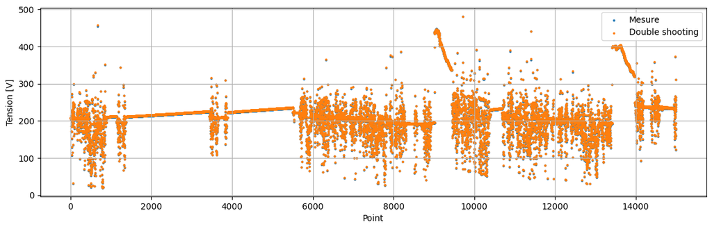

```python
n=15000

plt.figure(figsize=(14,4))

plt.scatter(
    np.arange(n),
    np.array(U_id[:n]),
    s=3,
    color=COLOR_U,
    label="Mesure"
)

plt.scatter(
    np.arange(n),
    np.array(U_2shoot[:n]),
    s=3,
    color=COLOR_I,
    label="Double shooting"
)

plt.ylabel("Tension [V]")
plt.xlabel("Point")
plt.legend()
plt.grid()
plt.show()
```

### Zoom local

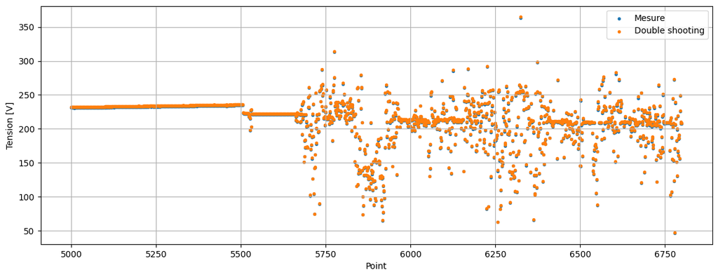

```
R² zoom : 0.9990943263885012
```

```python
ZOOM_END=ZOOM_START+ZOOM_LENGTH
x_zoom=np.arange(ZOOM_START,ZOOM_END)



plt.figure(figsize=(14,5))

plt.scatter(
    x_zoom,
    np.array(
        U_id[ZOOM_START:ZOOM_END]
    ),
    s=8,
    color=COLOR_U,
    label="Mesure"
)

plt.scatter(
    x_zoom,
    np.array(
        U_2shoot[ZOOM_START:ZOOM_END]
    ),
    s=8,
    color=COLOR_I,
    label="Double shooting"
)

plt.xlabel("Point")
plt.ylabel("Tension [V]")
plt.legend()
plt.grid()
plt.show()

print(
    "R² zoom :",
    float(
        r2_score(
            U_id[
                ZOOM_START:ZOOM_END
            ],
            U_2shoot[ZOOM_START:ZOOM_END]
        )
    )
)
```

## Résidus du double shooting

On définit :

$$ \varepsilon_k = U_k^{pred} - U_k^{mes}. $$

On vérifie :

- la moyenne ;
- l'écart-type ;
- la RMSE ;
- la distribution des résidus.

```python
residual_2shoot=np.array(
    U_2shoot-U_id
)

mean_2shoot=float(
    np.mean(
        residual_2shoot
    )
)

std_2shoot=float(
    np.std(
        residual_2shoot
    )
)

rmse_2shoot=float(
    np.sqrt(
        np.mean(
            residual_2shoot**2
        )
    )
)

print(
    "Moyenne résidu :",
    mean_2shoot,
    "V"
)

print(
    "Écart-type résidu :",
    std_2shoot,
    "V"
)

print(
    "RMSE :",
    rmse_2shoot,
    "V"
)

print(
    "R² :",
    R2_2shoot
)

print(
    "Bruit injecté :",
    VOLTAGE_NOISE_STD,
    "V"
)
```

```
Moyenne résidu : -0.0725696263410897 V
Écart-type résidu : 0.8033268576612624 V
RMSE : 0.8065980355215376 V
R² : 0.9997225589339985
Bruit injecté : 0.05 V
```

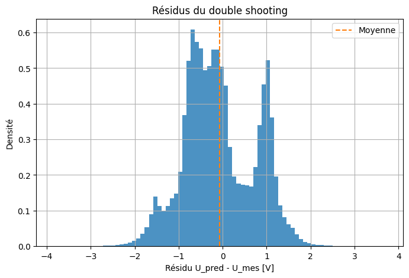

```python
plt.figure(figsize=(8,5))

plt.hist(
    residual_2shoot,
    bins=80,
    density=True,
    alpha=0.8,
    color=COLOR_U
)

plt.axvline(
    mean_2shoot,
    linestyle="--",
    color=COLOR_I,
    label="Moyenne"
)

plt.xlabel(
    "Résidu U_pred - U_mes [V]"
)

plt.ylabel("Densité")
plt.title(
    "Résidus du double shooting"
)

plt.legend()
plt.grid()
plt.show()
```

## Surface $R_0$ obtenue avec le double shooting

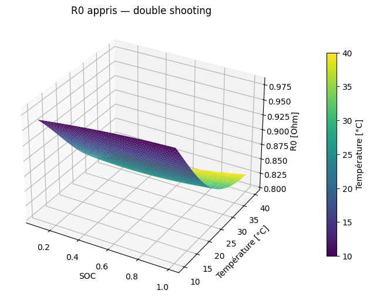

```python
plot_r0_surface(
    model_2shoot,
    "R0 appris — double shooting"
)
```

## SOC reconstruit avec le double shooting

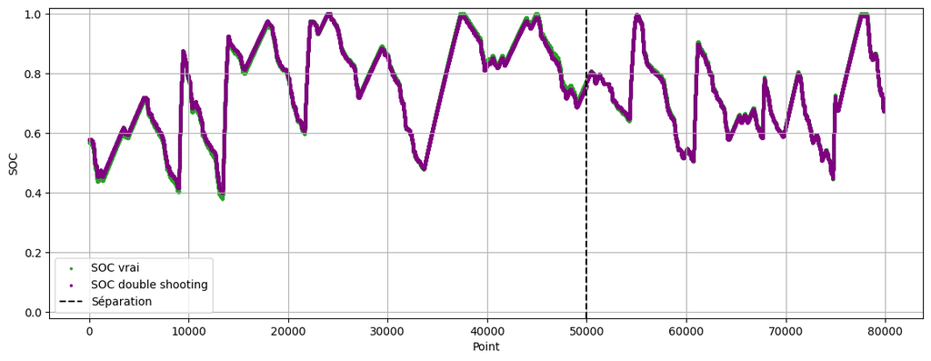

```python
SOC_TRUE_DOUBLE=SOC_true[
    train.index.to_numpy()
]

SOC_ERROR_DOUBLE=np.array(SOC_2shoot-SOC_TRUE_DOUBLE)

SOC_MAE_DOUBLE=float(np.mean(np.abs(SOC_ERROR_DOUBLE)))
SOC_RMSE_DOUBLE=float(np.sqrt(np.mean(SOC_ERROR_DOUBLE**2)))


plt.figure(figsize=(14,5))

plt.scatter(
    np.arange(
        len(SOC_TRUE_DOUBLE)
    ),
    np.array(
        SOC_TRUE_DOUBLE
    ),
    s=3,
    color=COLOR_SOC,
    label="SOC vrai"
)

plt.scatter(
    np.arange(
        len(SOC_2shoot)
    ),
    np.array(
        SOC_2shoot
    ),
    s=3,
    color="purple",
    label="SOC double shooting"
)

plt.axvline(
    CUT,
    linestyle="--",
    color="black",
    label="Séparation"
)

plt.ylim(
    -0.02,
    1.02
)

plt.xlabel("Point")
plt.ylabel("SOC")
plt.legend()
plt.grid()
plt.show()
```

```python
soc01_2shoot=float(
    jax.nn.sigmoid(
        model_2shoot.raw_soc01
    )
)

soc02_2shoot=float(
    jax.nn.sigmoid(
        model_2shoot.raw_soc02
    )
)

print(
    "SOC01 identifié :",
    soc01_2shoot
)

print(
    "SOC02 identifié :",
    soc02_2shoot
)

print(
    "SOC fin fenêtre 1 :",
    float(soc_end_1)
)

print(
    "Écart de continuité :",
    float(
        soc02_2shoot
        -soc_end_1
    )
)
```

```
SOC01 identifié : 0.5801839794296885
SOC02 identifié : 0.7733801333962163
SOC fin fenêtre 1 : 0.7604118898715657
Écart de continuité : 0.012968243524650536
```

## Validation du double shooting

On compare exactement les mêmes éléments que pour le single shooting :

- paramètres vrais et prédits ;
- SOC vrai et prédit ;
- $R_0(SOC,T)$ vrai et prédit.

```python
Cmax_2shoot=jnp.exp(model_2shoot.log_Cmax)
tau0_2shoot=jnp.exp(model_2shoot.log_tau0)
R_2shoot_id=jnp.exp(model_2shoot.log_R)

SOC02_TRUE=float(SOC_TRUE_DOUBLE[CUT])

PACK_DOUBLE=pd.DataFrame({
    "Grandeur":[
        "SOC01","SOC02","Cmax [Ah]","tau0 [s]",
        "R1 [Ohm]","R2 [Ohm]","R3 [Ohm]","R4 [Ohm]"
    ],
    "Vrai":[
        SOC0_TRUE,SOC02_TRUE,C_MAX_TRUE,TAU0_TRUE,
        float(R_RC_TRUE[0]),float(R_RC_TRUE[1]),
        float(R_RC_TRUE[2]),float(R_RC_TRUE[3])
    ],
    "Prédit":[
        soc01_2shoot,soc02_2shoot,float(Cmax_2shoot),float(tau0_2shoot),
        float(R_2shoot_id[0]),float(R_2shoot_id[1]),
        float(R_2shoot_id[2]),float(R_2shoot_id[3])
    ]
})

PACK_DOUBLE["Erreur relative [%]"]=100*np.abs(
    PACK_DOUBLE["Prédit"]-PACK_DOUBLE["Vrai"]
)/np.maximum(np.abs(PACK_DOUBLE["Vrai"]),1e-12)

PACK_DOUBLE
```

[output not shown]

### $R_0$ vrai vs prédit — double shooting

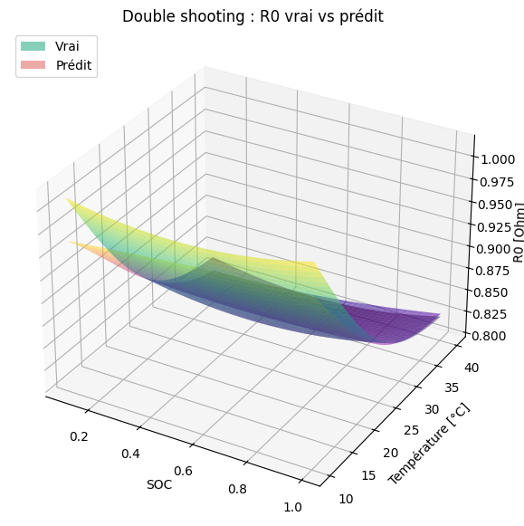

```
MAE surface R0 : 0.007567697504738552 Ohm
RMSE surface R0 : 0.010449933457043316 Ohm
```

```python
SOC_MESH,T_MESH,R0_DOUBLE=make_r0_grid(model_2shoot)
R0_REF=R0_true_function(SOC_MESH,T_MESH)

fig=plt.figure(figsize=(10,7))
ax=fig.add_subplot(111,projection="3d")

ax.plot_surface(
    np.array(SOC_MESH),np.array(T_MESH),np.array(R0_REF),
    cmap="viridis",alpha=0.55,linewidth=0
)

ax.plot_surface(
    np.array(SOC_MESH),np.array(T_MESH),np.array(R0_DOUBLE),
    cmap="plasma",alpha=0.55,linewidth=0
)

ax.set_xlabel("SOC")
ax.set_ylabel("Température [°C]")
ax.set_zlabel("R0 [Ohm]")
ax.set_title("Double shooting : R0 vrai vs prédit")

legend_handles=[
    Patch(facecolor=plt.cm.viridis(0.6),alpha=0.55,label="Vrai"),
    Patch(facecolor=plt.cm.plasma(0.6),alpha=0.55,label="Prédit")
]
ax.legend(handles=legend_handles,loc="upper left")

plt.show()

R0_ERR_DOUBLE=R0_DOUBLE-R0_REF

print("MAE surface R0 :",float(jnp.mean(jnp.abs(R0_ERR_DOUBLE))),"Ohm")
print("RMSE surface R0 :",float(jnp.sqrt(jnp.mean(R0_ERR_DOUBLE**2))),"Ohm")
```

Question : le premier $SOC_0$ reste peu précis. Comment pourrait-on améliorer encore la reconstruction du SOC sur une longue trajectoire ?

## Bilan single shooting / double shooting

On compare les deux formulations avec les mêmes indicateurs.

```python
SUMMARY_SHOOTING=pd.DataFrame({
    "Méthode":["Single shooting","Double shooting"],
    "R2 tension":[R2_voltage,R2_2shoot],
    "RMSE U [V]":[res_rmse,RMSE_2shoot],
    "MAE SOC":[SOC_MAE_SINGLE,SOC_MAE_DOUBLE],
    "RMSE SOC":[SOC_RMSE_SINGLE,SOC_RMSE_DOUBLE]
})

SUMMARY_SHOOTING
```

|  | Méthode | R2 tension | RMSE U [V] | MAE SOC | RMSE SOC |
| --- | --- | --- | --- | --- | --- |
| 0 | Single shooting | 0.999420 | 1.166181 | 0.010635 | 0.012201 |
| 1 | Double shooting | 0.999723 | 0.806598 | 0.006833 | 0.008255 |